# NDVI Linear regression model

```r
#import the data
library(readr)
ndvi <- read_csv("data/ndvi.csv")
head(ndvi) #to view the head of th data
```

| num | x | y | NDVI | Biomass |
| --- | --- | --- | --- | --- |
| 1 | 248841 | 1631803 | 0.4133229 | 3.4045822 |
| 2 | 248559 | 1632085 | 0.5601057 | 0.5009197 |
| 3 | 248841 | 1632085 | 0.6957662 | 7.3109499 |
| 4 | 249123 | 1632085 | 0.4521679 | 0.1553440 |
| 5 | 249405 | 1632085 | 0.6180948 | 3.1635110 |
| 6 | 249687 | 1632085 | 0.1672429 | 2.6643634 |

we want a linear regression model based on this formula Biomass = B0 + B1*NDVI

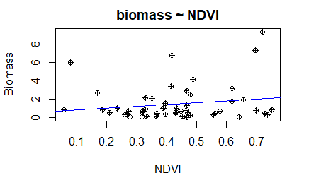

```r
#we can visualise the linear relationship between the NDVI and the BIOMASS with a scatterplot
plot(x = ndvi$NDVI, y = ndvi$Biomass, main = "biomass ~ NDVI",
     xlab = "NDVI", ylab = "Biomass",
     pch = 10, frame = TRUE)
abline(lm(Biomass ~ NDVI, data = ndvi), col = "blue")
```

```r
# scatterplot
```

We can compute the correlation between the two variables

```r
cor.test(ndvi$Biomass, ndvi$NDVI)
```

```
    Pearson's product-moment correlation

data:  ndvi$Biomass and ndvi$NDVI
t = 1.1793, df = 49, p-value = 0.244
alternative hypothesis: true correlation is not equal to 0
95 percent confidence interval:
 -0.1147051  0.4223762
sample estimates:
      cor
0.1661301
```

Our correlation is too closer to 0. So there is no correlation between the two variables.

Here we find how to explain the correlations

We can force to make the linear model but it will not be really significant. But anyway let’s try.

```r
#Our formula is Biomass = B0 + B1*NDVI
mbao_model <- lm(Biomass ~ NDVI , data = ndvi)# the formula
#we will print the model
mbao_model
```

```
Call:
lm(formula = Biomass ~ NDVI, data = ndvi)

Coefficients:
(Intercept)         NDVI
     0.6774       1.9443
```

Now that we have built the linear model, we also have established the relationship between the predictor and response in the form of a mathematical formula for biomass as a function for ndvi. For the above output, you can notice the ‘Coefficients’ part having two components: *Intercept*: 0.6774, *NDVI*: 1.9443. These are also called the beta coefficients. In other words,  
Biomass= Intercept + (β ∗ NDVI)

Before using our regression model, we have to ensure that it is statistically significant. We will print it summary to check.

```r
summary(mbao_model)
```

```
Call:
lm(formula = Biomass ~ NDVI, data = ndvi)

Residuals:
    Min      1Q  Median      3Q     Max
-1.8315 -1.1687 -0.7502  0.1010  7.2154

Coefficients:
            Estimate Std. Error t value Pr(>|t|)
(Intercept)   0.6774     0.7583   0.893    0.376
NDVI          1.9443     1.6487   1.179    0.244

Residual standard error: 1.98 on 49 degrees of freedom
Multiple R-squared:  0.0276,    Adjusted R-squared:  0.007754
F-statistic: 1.391 on 1 and 49 DF,  p-value: 0.244
```

We only have to check the p-value for the statistical significance. The p-Value is very important because, We can consider a linear model to be statistically significant only when both these p-Values are less that the pre-determined statistical significance level, which is ideally 0.05.

In our case the p-value is 0.244, greater than 0.05.

Our model is not significant statistically.